# AdaptM-coverData-Models

[figure not shown]

coverType Data Set - Modelling

Brian Carter

24 March, 2015

# Introduction

- Build out typical workflow of a data mining project on the **coverTye** dataset
- **coveType** column is the target (7 classes, class imbalance)
- Use *Python sklean* library
- Make use of **Pipelining** for feature transformation
- Plot results using Matplotlib normalised confusion matrix (equal weight to each class, regardless of size)
- Select approrpiate score for comparing models **F1_macro**
- **GridSearch** for the optimal set of parameters on best model
- Evaluate on the Test Data
- Training on 10% of data

# Data Loading

- Load covertype15.csv without columns in binary form (15 columns)
- Convert categoricals to dtype pd.Categoricals(). *(N.B. this is not valid dtype for storing)*

```python
#Libraries required
import platform
import numpy as np
import pandas as pd

#Currently pd.Categorical is not a valid dtype so they come in as objects. Need to convert.
colTypes = {'Elevation':np.float64,'Aspect':np.float64,'Slope':np.float64,'HD.Hydro':np.float64,
            'VD.Hyrdro': np.float64,'HD.Road': np.float64, 'HS.9am':np.float64,'HS.noon':np.float64,
            'HS.3pm':np.float64,'wildernessArea':pd.Categorical,'soilType':pd.Categorical,
            'climaticZone':pd.Categorical,'geologicZone':pd.Categorical,'coverType':pd.Categorical}

#Read in the data without binary encoding, 15 original columns
coverData = pd.read_csv("../Data/covtype15.csv",dtype=colTypes )
print ("CoverData Memory usage %s MB" % round(coverData.memory_usage().sum()/1000000,1))

#Set up values for converting to categorical
CATEGORYCOLUMNS = ['wildernessArea','soilType','climaticZone','geologicZone']

#Loop through and covert to category
for column in CATEGORYCOLUMNS:
    factors = list(coverData[column].unique())
    coverData[column] = pd.Categorical(coverData[column], categories=factors)

print ("CoverData Memory usage %s MB\n" % round(coverData.memory_usage().sum()/1000000,1))
coverData.head()
```

```
CoverData Memory usage 69.0 MB
CoverData Memory usage 53.0 MB
```

|  | Elevation | Aspect | Slope | HD.Hydro | VD.Hydro | HD.Road | HD.Fire | HS.9am | HS.noon | HS.3pm | wildernessArea | soilType | climaticZone | geologicZone | coverType |
| --- | --- | --- | --- | --- | --- | --- | --- | --- | --- | --- | --- | --- | --- | --- | --- |
| 0 | 3391.0 | 209.0 | 12.0 | 558.0 | 174 | 3306.0 | 211 | 251.0 | 173.0 | 552.0 | ComanchePeak | Bross | alpine | igneous and metamorphic | 1.SpruceFir |
| 1 | 3374.0 | 199.0 | 17.0 | 499.0 | 168 | 3276.0 | 212 | 252.0 | 170.0 | 576.0 | ComanchePeak | Bross | alpine | igneous and metamorphic | 1.SpruceFir |
| 2 | 3366.0 | 197.0 | 17.0 | 484.0 | 160 | 3252.0 | 213 | 252.0 | 168.0 | 600.0 | ComanchePeak | Bross | alpine | igneous and metamorphic | 1.SpruceFir |
| 3 | 3357.0 | 196.0 | 16.0 | 469.0 | 151 | 3228.0 | 214 | 252.0 | 167.0 | 624.0 | ComanchePeak | Bross | alpine | igneous and metamorphic | 1.SpruceFir |
| 4 | 3346.0 | 206.0 | 17.0 | 426.0 | 140 | 3223.0 | 207 | 253.0 | 177.0 | 633.0 | ComanchePeak | Bross | alpine | igneous and metamorphic | 1.SpruceFir |

## Create Input Features and Target

- Use generic X for feature input space
- use generic y for target variable - encode the values as numeric

10% of the data will be used for the training data. 5 Fold Cross Validation is used to create better approximation of the true test set errors .

*Using **sklearn.cross_validation** negates the need for a sepearte validation set.*

```python
import sklearn.cross_validation as cv
from sklearn import preprocessing

#store for Later use
targetLabels=['1.Spruce','2.Lodge','3.Ponder','4.Cotton','5.Aspen','6.Douglas','7.Krymmholz']


#Create generic X input feature space
X = coverData.drop('coverType', axis=1)

#Get the list of feature names. Will use later for extracting feature importances.
inputFeatures = list(pd.get_dummies(X).columns)

#Using LabelEncoder to encode the target variable coverType
le = preprocessing.LabelEncoder()
le.fit(coverData['coverType'])
y=le.transform(coverData['coverType'])

#Create splits for the training and test sets. Set random state for reproducibility
X_train, X_test, y_train, y_test = cv.train_test_split(X,y,test_size=0.9,random_state=79)
```

# Five Baseline Models

- Multionominal Naive Bayes
- Decision Tree - Depth 10
- Stochastic Gradient Descent - *log loss* - Logistic Regression

*Stoachastic Gradient Descent* is gradient descent bit only use a sample of the data for tuning each parameter. Converges quicker than gradient descent. Using *log* as the loss function makes it a logistic regression. Similar *hinge*(maximum-margin) loss makes it approximate an SVM.

- Stochastic Gradient Descent - hinge loss - SVM
- Random Forest - 100 Trees - Use 1/3 features at each split choice.

*Question: should max_features be increased when using dummy encoded variables ???*

## Model Pipeline

- The purpose of the pipeline is to assemble several steps together in chain

[figure not shown]

- Similar functionality in Spark ML API
- The Spark ML API pipeline concept is mostly inspired by the scikit-learn project. http://spark.apache.org/docs/latest/ml-guide.html

```python
#setup models
from sklearn.preprocessing import StandardScaler, MinMaxScaler,normalize,Normalizer

from sklearn.naive_bayes import MultinomialNB
from sklearn import tree
from sklearn.linear_model import SGDClassifier
from sklearn.ensemble import RandomForestClassifier
#from sklearn.svm import SVC
#from sklearn import neighbors

from sklearn.pipeline import make_pipeline

CLASSIFIERS1 = [make_pipeline(CategoricalTransformer(), MinMaxScaler(feature_range=(0,1)),
                             MultinomialNB()),

               make_pipeline(CategoricalTransformer(), StandardScaler(),
                             tree.DecisionTreeClassifier(criterion='gini',max_depth=10,min_samples_split=20)),

               make_pipeline(CategoricalTransformer(), StandardScaler(),
                             SGDClassifier(loss="log",n_jobs=4)),

               make_pipeline(CategoricalTransformer(), StandardScaler()
                             ,SGDClassifier(loss="hinge",n_jobs=4)),

               make_pipeline(CategoricalTransformer(), StandardScaler(),
                             RandomForestClassifier(n_estimators=100, max_features=22,max_depth=10,min_samples_split=20,
                                                    random_state=0,n_jobs=4))
              ]

MODELNAMES1 =  ['NaiveBayes','DecisionTree','SGD-Log','SGD-Hinge','RandomForest']
```

## Train Data Fit

- Loop through each of the classifiers and fit data
- Collect train data model evaluation metrics (time to fit, precision_macro, recall_macro, f1_macro, confusion matrix) *(time: some estimators using 4 cores: SGD, RandomForest)*
- Use **sklearn.metrics.classification** report.

```python
#run models
from sklearn.metrics import confusion_matrix,classification_report,f1_score
import time


#Lists to hold results
RESULTS1 = []
CONFUSIONMATRIX1 = []
CLASSIFICATIONREPORT1 = []
scores = ['precision_macro','recall_macro','f1_macro']

for pipe,model_name in zip(CLASSIFIERS1, MODELNAMES1):

    #Fit the model
    start = time.time()
    pipe.fit(X_train, y_train)
    totalMilliSec = round((time.time()-start)*1000,1)

    #Cross validation 5 k-fold get accurate estatimate of the training scores.
    train_scores = {score: cv.cross_val_score(pipe,X_train,y_train,cv=5,scoring=score) for score in scores}

    #Save the train scores in RESULTS
    results_dict = {'model': model_name ,
                    'timeMS' : totalMilliSec,
                    'precision' : round(train_scores['precision_macro'].mean(),3),
                    'recall' :    round(train_scores['recall_macro'].mean(),3),
                    'f1-score' :  round(train_scores['f1_macro'].mean(),3)
                   }

    RESULTS1.append(dict(results_dict))


    #Create Train prediction for calculating Decision Report and Confusion Matrix.
    y_train_pred = pipe.predict(X_train)

    # Create measures based on confusion matrix
    cm = confusion_matrix(y_train, y_train_pred)
    CONFUSIONMATRIX1.append(cm)

    classreport = classification_report(y_train, y_train_pred,target_names=targetLabels)
    CLASSIFICATIONREPORT1.append(classreport)
```

## Model Evaluation

For each of the models generate a classificaiton report with;

- recall - a measure of the classifiers completness. *((E.g.How many of the TRUE 1.Spruce are found. In first example Recall = 16474/(21247)) = 0.78
- precision - a measure of the classifiers exactness. *(E.g.How many of the rows predict 1.Spruce are TRUE 1.Spruce. In first example Precision = 16474/(16474+3864+0+0+13+1+434) = 0.79
- f1_score - balanced average of both = (precision*recall)/(precision+recall)
- Using the **macro** average over all classes - results in each classes being given equal importance. A *micro* average would take into account class size.
- A normalized confusion matrix on the train set is used to plot on a *heatmap*. Normalizing gives each class equal weight. The darker the colour is better. Looking for a dark diagonal.

**Not used**

- accuracy - doesn't make sense with class imbalance. Will favour majority classes. Is calculated for comprhension.
- cohen kappa
  - classification accuracy normalized by the imbalance of the clsses in the data. Not an agreed measure for classification problems. The kappa score (see docstring) is a number between -1 and 1. Scores above .8 are generally considered good agreement; zero or lower means no agreement (practically random labels).

|  | model | timeMS | f1-score | precision | recall |
| --- | --- | --- | --- | --- | --- |
| 0 | NaiveBayes | 201.0 | 0.448 | 0.470 | 0.490 |
| 1 | DecisionTree | 633.0 | 0.659 | 0.749 | 0.617 |
| 2 | SGD-Log | 545.0 | 0.445 | 0.502 | 0.450 |
| 3 | SGD-Hinge | 455.0 | 0.453 | 0.523 | 0.453 |
| 4 | RandomForest | 4039.0 | 0.659 | 0.814 | 0.608 |

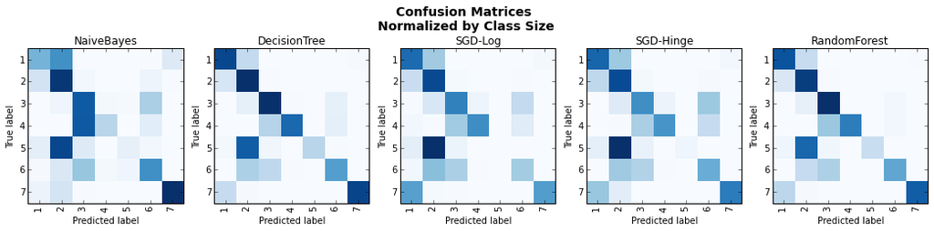

```python
#print out model results
multiConfusion(CONFUSIONMATRIX1,MODELNAMES1)
pd.DataFrame(RESULTS1,columns=['model','timeMS','f1-score','precision','recall'])
```

- The DecisionTree has the best **F1_Score** using cross validation = 0.66.

```python
#interactive element↔
```

```
Classification report for classifier DecisionTree:
             precision    recall  f1-score   support

   1.Spruce       0.79      0.78      0.78     21247
    2.Lodge       0.80      0.85      0.83     28230
   3.Ponder       0.82      0.85      0.83      3596
   4.Cotton       0.86      0.67      0.75       277
    5.Aspen       0.92      0.25      0.39       939
  6.Douglas       0.71      0.48      0.58      1728
7.Krymmholz       0.90      0.78      0.84      2084

avg / total       0.80      0.80      0.80     58101


46495 rows of a total 58101 correctly classified

Confusion matrix:
[[16474  4619     4     0     4     2   144]
 [ 3864 24081   171     2    14    58    40]
 [    0   260  3053    17     1   261     4]
 [    0     0    71   185     0    21     0]
 [   13   662    28     0   232     4     0]
 [    1   486   394    10     0   837     0]
 [  434    17     0     0     0     0  1633]]
```

```
<function __main__.resultshow>
```

# Decision Trees

The DecisionTree had max depth of 10 nodes and returned the best *F1* score. This tree is re-creatd and other variants of Decision Trees are created;

- Decision Tree - Max Depth 5
- Decision Tree - Max Depth 10 (previous Tree)
- Decision Tree - using *entropy* as the criteria for splitting.

*“Gini” will tend to find the largest class, and “entropy” tends to find groups of classes that make up ~50% of the data((http://paginas.fe.up.pt/~ec/files_1011/week%2008%20-%20Decision%20Trees.pdf))*

- Weighted Tree - use the class distribution to inversely weight trees so smaller classes have greater weight.
- Full Tree - no limit on depth, stopping criteria is 20 rows per leaf

*Full Tree will overfit the data. Sklearn does not provide method for pruning at present*

```python
#Determine the weights by inverse proportion
inverseFreq  = 1./ np.bincount(y_train)
coverTypeWeights = inverseFreq / np.mean(inverseFreq)
#DecisionTreeClassifier requires dictionary of weights
coverTypeWeights = dict(zip(range(7), coverTypeWeights))

CLASSIFIERS2 = [make_pipeline(CategoricalTransformer(), StandardScaler(),
                             tree.DecisionTreeClassifier(criterion='gini',max_depth=5,min_samples_split=20)),

                make_pipeline(CategoricalTransformer(), StandardScaler(),
                             tree.DecisionTreeClassifier(criterion='gini',max_depth=10,min_samples_split=20)),

                make_pipeline(CategoricalTransformer(), StandardScaler(),
                             tree.DecisionTreeClassifier(criterion='entropy',max_depth=10,min_samples_split=20)),

                make_pipeline(CategoricalTransformer(), StandardScaler(),
                             tree.DecisionTreeClassifier(criterion='gini',max_depth=10,min_samples_split=20,
                                                         class_weight=coverTypeWeights)),

                make_pipeline(CategoricalTransformer(), StandardScaler(),
                             tree.DecisionTreeClassifier(criterion='gini',max_depth=None,min_samples_split=20))]

MODELNAMES2 =  ['Depth5 Tree','Original Tree','Entropy Tree','Weighted Tree','FullTree']
```

```python
#Lists to hold results
RESULTS2 = []
CONFUSIONMATRIX2 = []
CLASSIFICATIONREPORT2 = []

scores = ['precision_macro','recall_macro','f1_macro']

for pipe,model_name in zip(CLASSIFIERS2, MODELNAMES2):

    #Fit the model
    start = time.time()
    pipe.fit(X_train, y_train)
    totalMilliSec = round((time.time()-start)*1000,1) #milliseconds

    #Cross validation 5 k-fold get accurate estatimate of the training scores.
    train_scores = {score: cv.cross_val_score(pipe,X_train,y_train,cv=5,scoring=score) for score in scores}

    #Extract the feature importance
    featureImport=(pipe.steps[2][1].feature_importances_).round(3)
    topFeautureIndex = featureImport.argsort()[5:][::-1]

    #Save the train scores in RESULTS
    results_dict = {'model': model_name ,
                    'timeMS' : totalMilliSec,
                    'precision' : round(train_scores['precision_macro'].mean(),3),
                    'recall' :    round(train_scores['recall_macro'].mean(),3),
                    'f1-score' :  round(train_scores['f1_macro'].mean(),3),
                    'top feature' :   [inputFeatures[i] for i in topFeautureIndex],
                    'feature score' :    [featureImport[i] for i in topFeautureIndex]
                   }

    RESULTS2.append(dict(results_dict))


    #Create Train prediction for calculating Decision Report and Confusion Matrix.
    y_train_pred = pipe.predict(X_train)

    # Create measures based on confusion matrix
    cm = confusion_matrix(y_train, y_train_pred)
    CONFUSIONMATRIX2.append(cm)

    classreport = classification_report(y_train, y_train_pred,target_names=targetLabels)
    CLASSIFICATIONREPORT2.append(classreport)
```

|  | model | timeMS | f1-score | precision | recall | top feature | feature score |
| --- | --- | --- | --- | --- | --- | --- | --- |
| 0 | Depth5 Tree | 533.0 | 0.510 | 0.554 | 0.503 | [Elevation, climaticZone_alpine, climaticZone_... | [0.712, 0.068, 0.064, 0.057, 0.028, 0.018, 0.0... |
| 1 | Original Tree | 613.0 | 0.658 | 0.749 | 0.617 | [Elevation, HD.Road, HS.3pm, climaticZone_alpi... | [0.516, 0.086, 0.072, 0.045, 0.042, 0.036, 0.0... |
| 2 | Entropy Tree | 734.0 | 0.685 | 0.734 | 0.661 | [Elevation, climaticZone_alpine, HD.Road, HS.3... | [0.583, 0.066, 0.064, 0.06, 0.032, 0.028, 0.02... |
| 3 | Weighted Tree | 637.0 | 0.594 | 0.547 | 0.760 | [Elevation, climaticZone_alpine, HD.Road, HS.3... | [0.418, 0.145, 0.089, 0.067, 0.061, 0.033, 0.0... |
| 4 | FullTree | 857.0 | 0.734 | 0.746 | 0.724 | [Elevation, HD.Road, HS.3pm, HD.Hydro, VD.Hydr... | [0.371, 0.127, 0.117, 0.052, 0.041, 0.033, 0.0... |

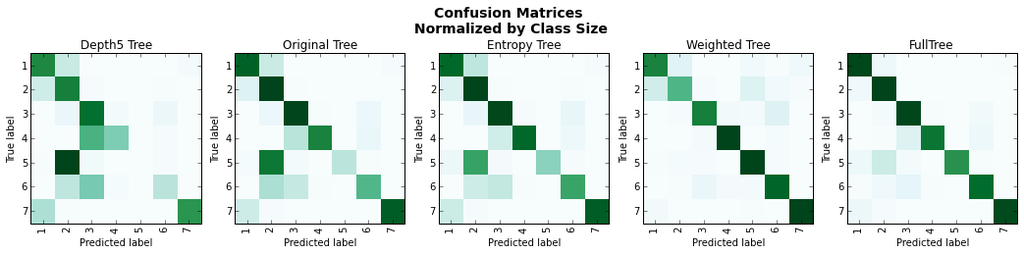

```python
#print out model results
multiConfusion(CONFUSIONMATRIX2,MODELNAMES2,cmap=plt.cm.BuGn)
pd.DataFrame(RESULTS2,columns=['model','timeMS','f1-score','precision','recall','top feature','feature score'])
```

- The Full Tree has the best **F1_Score** using cross validation = 0.734
- Without pruning it has overfit the data
- The Decision Tree using Entropy has **F1_Score** using cross validation = 0.685

```python
#interactive element↔
```

```
Classification report for classifier Entropy Tree:
             precision    recall  f1-score   support

   1.Spruce       0.78      0.75      0.76     21247
    2.Lodge       0.79      0.84      0.82     28230
   3.Ponder       0.84      0.83      0.83      3596
   4.Cotton       0.85      0.75      0.80       277
    5.Aspen       0.87      0.35      0.49       939
  6.Douglas       0.68      0.56      0.61      1728
7.Krymmholz       0.87      0.78      0.82      2084

avg / total       0.79      0.79      0.79     58101


45872 rows of a total 58101 correctly classified

Confusion matrix:
[[15954  5063     1     0     9    13   207]
 [ 4091 23816   113     2    41   123    44]
 [    4   287  2987    24     0   294     0]
 [    0     0    53   208     0    16     0]
 [   60   527    16     0   325    11     0]
 [    5   350   400    11     0   962     0]
 [  443    21     0     0     0     0  1620]]
```

```
<function __main__.resultshow>
```

# Entropy, One-vs-Rest, Ensemble

Building on the increase in the **F1-score** using *Entrop* splitting criteria, return to a previous ensemble model *RandomForest* and alter the splitting criterion.

- Decision Tree Entropy
- Random Forest with DT Entropy

Introduce a *OneVsRestClassifier*. This increases the complexity as in effect 7 models are trained, one for each class.

- One-vs-Rest DT
- One-vs-Rest RF

Introduce *AdaBoost* model. Ensemble method at each iteration focus on missclassified rows. Should force algorithm to focus on smaller classes. *(NB AdaBoost not easily parallisable - takes long time to fit)*.

- AdaBoost

```python
from sklearn.multiclass import OneVsRestClassifier
from sklearn.ensemble import AdaBoostClassifier

CLASSIFIERS3 = [make_pipeline(CategoricalTransformer(), StandardScaler(),
                             tree.DecisionTreeClassifier(criterion='entropy',max_depth=10,min_samples_split=20)),

                make_pipeline(CategoricalTransformer(), StandardScaler(),
                             RandomForestClassifier(n_estimators=100, max_features=22,max_depth=10,min_samples_split=20,
                                                    random_state=0,criterion='entropy',n_jobs=4)),

                make_pipeline(CategoricalTransformer(), StandardScaler(),
                              OneVsRestClassifier(tree.DecisionTreeClassifier(criterion='entropy',
                                                                              max_depth=10,min_samples_split=20),n_jobs=4)),

                 make_pipeline(CategoricalTransformer(), StandardScaler(),
                              OneVsRestClassifier(
                                RandomForestClassifier(n_estimators=100,max_features=22,max_depth=10,
                                                       min_samples_split=20,random_state=0,criterion='entropy',n_jobs=4))),

                 #No version of xgboost for windows use AdaBoost instead.
                 make_pipeline(CategoricalTransformer(), StandardScaler(),
                              AdaBoostClassifier(tree.DecisionTreeClassifier(max_depth=10),algorithm="SAMME.R",
                                                 n_estimators=100,learning_rate=0.5))
               ]

MODELNAMES3 =  ['Entropy Tree','RF_Entropy','OneVs-Tree','OneVs-RF','AdaBoost']
```

```python
import warnings
warnings.filterwarnings("ignore")

#Lists to hold results
RESULTS3 = []
CONFUSIONMATRIX3 = []
CLASSIFICATIONREPORT3 = []

scores = ['precision_macro','recall_macro','f1_macro']

for pipe,model_name in zip(CLASSIFIERS3, MODELNAMES3):

    #Fit the model
    start = time.time()
    pipe.fit(X_train, y_train)
    totalMilliSec = round((time.time()-start)*1000,1)

    #Cross validation 5 k-fold get accurate estatimate of the training scores.
    train_scores = {score: cv.cross_val_score(pipe,X_train,y_train,cv=5,scoring=score) for score in scores}

    #Save the train scores in RESULTS
    results_dict = {'Model': model_name ,
                    'TimeMS' : totalMilliSec,
                    'precision' : round(train_scores['precision_macro'].mean(),3),
                    'recall' :    round(train_scores['recall_macro'].mean(),3),
                    'f1-score' :  round(train_scores['f1_macro'].mean(),3)
                   }

    RESULTS3.append(dict(results_dict))

    #Create Train prediction for calculating Decision Report and Confusion Matrix.
    y_train_pred = pipe.predict(X_train)
    #y_test_pred = pipe.predict(X_test)

    # Create measures based on confusion matrix
    cm = confusion_matrix(y_train, y_train_pred)
    CONFUSIONMATRIX3.append(cm)

    classreport = classification_report(y_train, y_train_pred,target_names=targetLabels)
    CLASSIFICATIONREPORT3.append(classreport)
```

|  | Model | TimeMS | f1-score | precision | recall |
| --- | --- | --- | --- | --- | --- |
| 0 | Entropy Tree | 777.0 | 0.686 | 0.732 | 0.659 |
| 1 | RF_Entropy | 5273.0 | 0.675 | 0.802 | 0.629 |
| 2 | OneVs-Tree | 2325.0 | 0.695 | 0.759 | 0.662 |
| 3 | OneVs-RF | 23711.0 | 0.671 | 0.814 | 0.621 |
| 4 | AdaBoost | 48696.0 | 0.726 | 0.828 | 0.675 |

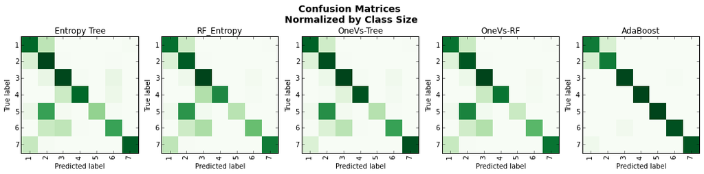

```python
multiConfusion(CONFUSIONMATRIX3,MODELNAMES3,cmap=plt.cm.Greens)
pd.DataFrame(RESULTS3)
```

- AdaBoost is the best performing algorithm, F1_score = 0.726
- OneVsRest with a Decision Tree using *entropy is next best, F1_score = 0.695
- AdaBoost takes a long time to train compared to a Decision Tree.
- *F1 score* improved with *OneVstRest - DT* - use this for the Grid Search

```python
#interactive element
def resultshow(model):

    #model = w.value
    select = MODELNAMES3.index(model)

    print("Classification report for classifier %s:\n%s\n"
      % (MODELNAMES3[select],CLASSIFICATIONREPORT3[select]))

    print '%d rows of a total %d correctly classified' % (sum(np.diagonal(CONFUSIONMATRIX3[select])),
                                                      CONFUSIONMATRIX3[select].sum())

    print("\nConfusion matrix:\n%s" % CONFUSIONMATRIX3[select])

interact(resultshow,model = widgets.Dropdown(options=MODELNAMES3,
                                             value=MODELNAMES3[4],
                                             description='Select to display model results:'))
```

```
Classification report for classifier AdaBoost:
             precision    recall  f1-score   support

   1.Spruce       0.77      0.82      0.79     21247
    2.Lodge       0.86      0.81      0.84     28230
   3.Ponder       0.98      0.99      0.98      3596
   4.Cotton       1.00      1.00      1.00       277
    5.Aspen       1.00      1.00      1.00       939
  6.Douglas       0.98      0.96      0.97      1728
7.Krymmholz       0.97      0.95      0.96      2084

avg / total       0.84      0.84      0.84     58101


48825 rows of a total 58101 correctly classified

Confusion matrix:
[[17413  3767     0     0     0     0    67]
 [ 5222 23005     2     0     1     0     0]
 [    0     0  3560     0     0    36     0]
 [    0     0     0   277     0     0     0]
 [    0     3     0     0   936     0     0]
 [    0     0    72     0     0  1656     0]
 [  106     0     0     0     0     0  1978]]
```

```
<function __main__.resultshow>
```

# Grid Search

## Search Parameters

Use this model and iterate of all possible comibinations of four *DecisionTreeClassifier* parameters.

- Maximum Depth - how many levels the tree contains
- Minimum Splits - cutoff, if a leaf node is below threshold no further splitting occurs.
- Maximum Features to Consider - at each split take all the reamining features in account or a sample
- Class Weights
  - Utilising *OneVsRest* alter the weights so that each class has equal importance. Will favour smaller classes.

**Intuition** - The maximum depth tree will be favoured with the smallest number of rows per leaf. There will be tradeoff between these two values.

**GridSearch** - has many iterations. In order to minimise computation time, transform the training data first rather than for each iteration. Execute it in parallel with *n_jobs* parameter.

**Scoring** - Scoring will be set to *f1-macro*.

```python
from sklearn.grid_search import GridSearchCV

#parameters to search
max_depthS = [10,20,30]
min_samples_splitS = [10,20,30]
max_featuresS = [0.5,'sqrt','log2',None]
class_weightS = [None,{0:0.5,1:0.5}]

#Need to include estimator__ when model is inside OnveVsRestClassifier

parameterGrid = {'estimator__max_depth' : max_depthS, 'estimator__min_samples_split' : min_samples_splitS,
                  'estimator__max_features': max_featuresS,'estimator__class_weight' : class_weightS }

print (parameterGrid)

#Create the Grid Search, verbose indicates how details message are printed. Set to 1. Increase the number of cores to six.
grid_search = GridSearchCV(OneVsRestClassifier(tree.DecisionTreeClassifier(criterion='entropy')),
                                               parameterGrid, verbose=1,cv=5,n_jobs=6,scoring='f1_macro')

#Calculate the transformed Training Data.
X_trainTransformed =  StandardScaler().fit_transform(pd.get_dummies(X_train))

#Set up model
```

```
{'estimator__class_weight': [None, {0: 0.5, 1: 0.5}], 'estimator__min_samples_split': [10, 20, 30], 'estimator__max_depth': [10, 20, 30], 'estimator__max_features': [0.5, 'sqrt', 'log2', None]}
```

```python
#Fit the prid search to the X_Transformed Data.

#Need to turn off warnings here as joblib deprication warning appearing.
import warnings
warnings.filterwarnings('ignore')

start = time.time()
grid_search.fit(X_trainTransformed,y_train)
end = time.time()
```

```
[Parallel(n_jobs=6)]: Done  38 tasks      | elapsed:   11.9s
[Parallel(n_jobs=6)]: Done 188 tasks      | elapsed:  1.3min
[Parallel(n_jobs=6)]: Done 360 out of 360 | elapsed:  2.6min finished
```

```
Fitting 5 folds for each of 72 candidates, totalling 360 fits
```

```python
print 'Grid Search Execution Time (minutes) %0.3f' % ((end-start)/60)
print 'Best f1_macro score: %0.3f' % grid_search.best_score_
print 'Best parameters set:'
best_parameters = grid_search.best_estimator_.get_params()
for param_name in sorted(parameterGrid.keys()):
    print '\t%s: %r' % (param_name, best_parameters[param_name])
```

```
Grid Search Execution Time (minutes) 2.625
Best f1_macro score: 0.742
Best parameters set:
	estimator__class_weight: None
	estimator__max_depth: 30
	estimator__max_features: None
	estimator__min_samples_split: 30
```

## Predict: Test Data

The **f1_score*** (0.74) is greated than that of a *DecisionTreeClassifier* grown to maximum depth and the *AdaBoost* model.

The *GridSearch* optimal set of components has been noted to alternate between

[output not shown]

May require more crossfolds, or extra examples to verify. Both f1_scores are similar.

The best set of parameters is used to **predict** on the test set.

### Final Results

```python
#gnerate andprint out results on test set↔
```

```
Best Train model: 54831 rows of a total 58101 correctly classified
Overall Accuracy 0.944 :

################### TEST RESULTS ####################
Test Set: F1_macro score 0.752
Test Data: 443416 rows of a total 522911 correctly classified
Overall Accuracy 0.848 :

################### TEST SET REPORT ####################
             precision    recall  f1-score   support

   1.Spruce       0.87      0.83      0.85    190593
    2.Lodge       0.87      0.89      0.88    255071
   3.Ponder       0.83      0.83      0.83     32158
   4.Cotton       0.75      0.67      0.71      2470
    5.Aspen       0.65      0.51      0.57      8554
  6.Douglas       0.70      0.66      0.68     15639
7.Krymmholz       0.67      0.85      0.75     18426

avg / total       0.85      0.85      0.85    522911
```

## Conclusions

**Further Work**

- Improvement may be obtained by creating a pareto optimisation fuction with accuracy and f1_macro score for the grid search*
- More data preperation - outlier analysis
- No feature subsetting - feature selection methods implmeneted.

## Reingold D3 Tree

Extract the rules from the tree for visualisation, not very informative and not working with OneVsRestClassifier.

- Limit to maximum depth of 4 for illustrative purposes

```python
#Setup data for DecisionClassifier with no pipeline
X_trainB = pd.get_dummies(X_train)

#Dont' trasnform for readability
#X_trainB = preprocessing.StandardScaler().fit_transform(X_trainB)


#Create the model
clfRein =   tree.DecisionTreeClassifier(criterion='entropy',max_depth=4,min_samples_split=10)
#Fit the model
clfRein.fit(X_trainB,y_train)

featureNames = list(pd.get_dummies(X_train).columns)
#Pass to function rules()
clfRules = rules(clfRein, featureNames, targetLabels)

#Write out the json file.
import json
with open('coverData.json', 'w') as outfile:
    json.dump(clfRules, outfile)
```

[Click Here for Reingold-Tilfor Tree Representation](../C:/Users/IBM_ADMIN/Desktop/github/coverData/DataModel_with_sklearn/ReinfoldTreeDisplay.html)

# Appendices

## A: Functions

### convert to pd.Categorical

```python
#Function to convert column in data frame with dtype = Categorical to a binary represenation
#http://tomaugspurger.github.io/categorical-pipelines.html

"""
    Parameters
    ----------
    X : Dataframe

    Methods
    ----------
    fit : determine columns for conversion(was missing return in docs)
    transfom: apply conversion
    inverse_transform: return to original - not tested or used here
"""




from itertools import chain
from sklearn.pipeline import TransformerMixin

class CategoricalTransformer(TransformerMixin):

    def fit(self, X, y=None, *args, **kwargs):
        self.columns_ = X.columns
        self.cat_columns_ = X.select_dtypes(include=['category']).columns
        self.non_cat_columns_ = X.columns.drop(self.cat_columns_)

        self.cat_map_ = {col: X[col].cat.categories
                         for col in self.cat_columns_}
        self.ordered_ = {col: X[col].cat.ordered
                         for col in self.cat_columns_}

        self.dummy_columns_ = {col: ["_".join([col, v])
                                     for v in self.cat_map_[col]]
                               for col in self.cat_columns_}
        self.transformed_columns_ = pd.Index(
            self.non_cat_columns_.tolist() +
            list(chain.from_iterable(self.dummy_columns_[k]
                                     for k in self.cat_columns_))
        )

        return self

    def transform(self, X, y=None, *args, **kwargs):
        return (pd.get_dummies(X)
                  .reindex(columns=self.transformed_columns_)
                  .fillna(0))

    def inverse_transform(self, X):
        X = np.asarray(X)
        series = []
        non_cat_cols = (self.transformed_columns_
                            .get_indexer(self.non_cat_columns_))
        non_cat = pd.DataFrame(X[:, non_cat_cols],
                               columns=self.non_cat_columns_)
        for col, cat_cols in self.dummy_columns_.items():
            locs = self.transformed_columns_.get_indexer(cat_cols)
            codes = X[:, locs].argmax(1)
            cats = pd.Categorical.from_codes(codes, self.cat_map_[col],
                                             ordered=self.ordered_[col])
            series.append(pd.Series(cats, name=col))
        # concats sorts, we want the original order
        df = (pd.concat([non_cat] + series, axis=1)
                .reindex(columns=self.columns_))
        return df

self = CategoricalTransformer()  # for testing later
```

### Print out five confusion matrices

```python
#Function to plot 5 confusion matrices.
import matplotlib
import matplotlib.pyplot as plt
%matplotlib inline

"""
    Parameters
    ----------
    CM : list of confusion matrices as returned from sklearn.metrics.onfusion_matrix
    MN : list of model names
    cmap : colour palette from matplotlib - set to plt.cm.Blues
"""

def multiConfusion(CM,MN,cmap=plt.cm.Blues):
    numberPlots = len(CM)
    fig, axs = plt.subplots(1,numberPlots, figsize=(18,4), facecolor='w', edgecolor='k')
    fig.suptitle("Confusion Matrices \n Normalized by Class Size", fontsize=14,fontweight='bold')

    axs = axs.ravel()

    for c,m,i in zip(CM,MN,range(len(MN))) :
        cm_normalized = c.astype('float') / c.sum(axis=1)[:, np.newaxis]
        axs[i].imshow(cm_normalized, interpolation='nearest', cmap=cmap)
        axs[i].set_title(m)
        tick_marks = np.arange(len(targetLabels)+1)
        axs[i].set_xticklabels(tick_marks, rotation=90)
        axs[i].set_yticklabels(tick_marks)
        axs[i].set_ylabel('True label')
        axs[i].set_xlabel('Predicted label')
```

### Extract Decision Tree Rules

```python
#http://planspace.org/20151129-see_sklearn_trees_with_d3/
def rules(clf, features, labels, node_index=0):

    """Structure of rules in a fit decision tree classifier

    Parameters
    ----------
    clf : DecisionTreeClassifier
        A tree that has already been fit.

    features, labels : lists of str
        The names of the features and labels, respectively.

    """
    node = {}
    if clf.tree_.children_left[node_index] == -1:  # indicates leaf
        count_labels = zip(clf.tree_.value[node_index, 0], labels)
        node['name'] = ', '.join(('{} of {}'.format(int(count), label)
                                  for count, label in count_labels))
    else:
        feature = features[clf.tree_.feature[node_index]]
        threshold = clf.tree_.threshold[node_index]
        node['name'] = '{} > {}'.format(feature, threshold)
        left_index = clf.tree_.children_left[node_index]
        right_index = clf.tree_.children_right[node_index]
        node['children'] = [rules(clf, features, labels, right_index),
                            rules(clf, features, labels, left_index)]
    return node
```

## B: Example Concepts

### Transformers

```python
import pandas as pd
from sklearn import preprocessing
import numpy as np

#Create matrix with mixture of value types (float, int, binary)
X = pd.DataFrame(np.array([[ 1.3, -10,  0],[ 2.4,  7,  1],[ 0.2,  2, 0]]))
print X
```

```
     0     1    2
0  1.3 -10.0  0.0
1  2.4   7.0  1.0
2  0.2   2.0  0.0
```

```python
#MinMaxScaler scales between a range, presevers binary info
print pd.DataFrame(preprocessing.MinMaxScaler(feature_range=(0,1)).fit_transform(X))
```

```
     0         1    2
0  0.5  0.000000  0.0
1  1.0  1.000000  1.0
2  0.0  0.705882  0.0
```

```python
#scales to unit norm
print pd.DataFrame(preprocessing.normalize(X))
```

```
          0         1         2
0  0.128915 -0.991656  0.000000
1  0.321403  0.937425  0.133918
2  0.099504  0.995037  0.000000
```

```python
#scales to standard normal form, mean 0, sd. = 1
print pd.DataFrame(preprocessing.StandardScaler().fit_transform(X))
```

```
          0         1         2
0  0.000000 -1.355081 -0.707107
1  1.224745  1.027992  1.414214
2 -1.224745  0.327089 -0.707107
```

### PCA with two components

The 10 numerical variables can be reduced for a smaller representation. This ignores any associated with the class. LDA might be better if this were required.

```python
#Create a copy of the training dataset
clusterDF=X_train.ix[:,0:17]
clusterDF['y_train']=y_train

from sklearn.decomposition import PCA

#scale Data to standard Normal
scaledData = preprocessing.StandardScaler().fit_transform(clusterDF.ix[:,0:10])
scaledData = preprocessing.normalize(clusterDF.ix[:,0:10])

for i in range(1,3):
    pca = PCA(n_components=i)
    pca.fit(scaledData)
    variance=sum(pca.explained_variance_ratio_)
    print('Explained variance ratio of the %s components with normalized data: %s'% (i,variance))

    #Save first two pca for plot
    if i == 2:
        saveVariance = variance
        numericPCA = pca.transform(scaledData)
        clusterDF['PC1']=numericPCA[:,0]
        clusterDF['PC2']=numericPCA[:,1]
```

```
Explained variance ratio of the 1 components with normalized data: 0.557638403311
Explained variance ratio of the 2 components with normalized data: 0.950945936093
```

```python
#Function to plot 5 confusion matrices.
%matplotlib inline
import matplotlib
import matplotlib.pyplot as plt
import matplotlib.colors as colors
from matplotlib.colors import rgb2hex
colormap = plt.get_cmap('hsv')

#@colormap is set
#@breaks varied depending on number of levels. E.g. Warning: yes|no has two levels.

def colors_at_breaks(colormap, breaks):
    return [rgb2hex(colormap(x)) for x in breaks]

#Code for color breaks based on answer to;
#http://stackoverflow.com/questions/19322768/how-to-determine-colors-at-intervals-in-a-matplotlib-colormap
```

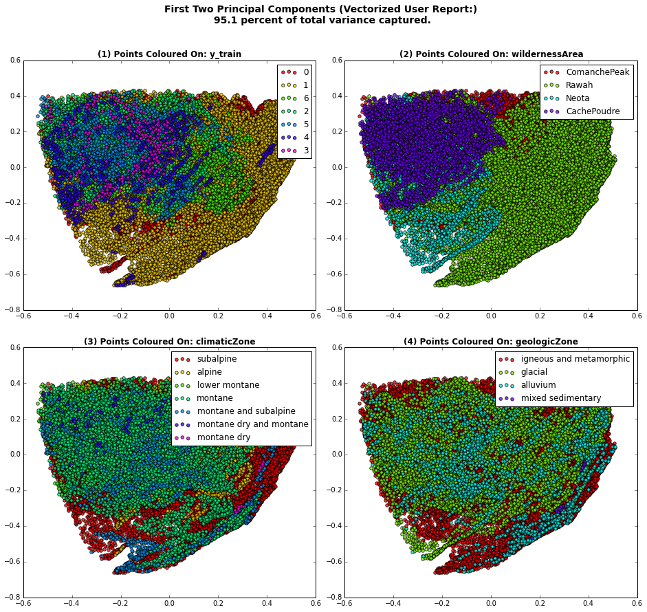

```python
columnlist=['y_train','wildernessArea','climaticZone','geologicZone'] #'Tested'

#Create plot with 3 rows and 2 columns
fig, axs = plt.subplots(2,2, figsize=(16, 14), facecolor='w', edgecolor='k')
fig.subplots_adjust(hspace = .15, wspace=.1)
plt.suptitle(("First Two Principal Components (Vectorized User Report:) \n %0.1f percent of total variance captured."
            % (saveVariance*100)), fontsize=14,fontweight='bold')


#Create index of all the subplots.
axs = axs.ravel()

for col in range(len(columnlist)):

    levelslist=list(clusterDF[columnlist[col]].unique())
    split=float(1.0/(len(list(clusterDF[columnlist[col]].unique()))))
    breaks=np.arange(0.0,1.0,split)
    colors=colors_at_breaks(colormap,breaks)

    plt.figure()
    for c, i, target_name in zip(colors, levelslist, levelslist):
        axs[col].scatter(clusterDF['PC1'][(clusterDF[columnlist[col]]==i)],
                    clusterDF['PC2'][(clusterDF[columnlist[col]]==i)],c=c,label=target_name,alpha=0.75)
        axs[col].set_title("("+(str(col+1)+") Points Coloured On: "+columnlist[col]),fontweight='bold')
        axs[col].legend()

#Uncomment to save the figure
#fig.savefig('PCAPlot_2_4.png',dpi=96,bbox_inches='tight')
```